# 주제분석 3주차 패키지 과제 - 3팀 선형대수학팀 김지민

```python
import pandas as pd
import numpy as np

import matplotlib.pyplot as plt
import seaborn as sns

from category_encoders.cat_boost import CatBoostEncoder
import lightgbm as lgb
from lightgbm import LGBMModel,LGBMRegressor
```

```python
train = pd.read_csv('train.csv')
test=  pd.read_csv('test.csv')

train_x = train.drop(['price'], axis = 1)
train_y = train.loc[:, ['price']]
test_x = test.drop(['price'], axis = 1)
test_y = np.sqrt(test.loc[:, ['price']])

feature_list = list(train_x.columns)

CBE_encoder = CatBoostEncoder()
train_cbe = CBE_encoder.fit_transform(train_x[feature_list], train_y)
test_cbe = CBE_encoder.transform(test_x[feature_list])

best_lgbm_reg = LGBMRegressor(learning_rate = 0.3)
best_lgbm_reg.fit(train_cbe, train_y)
```

```
LGBMRegressor(learning_rate=0.3)
```

## Chapter 1. Interpretable ML

### 1.1 모델 불러오기

```python
import pickle
import joblib
```

```python
lgbm_model = joblib.load('lgbm.pkl')
```

### 1.2 Feature Importance 확인과 해석

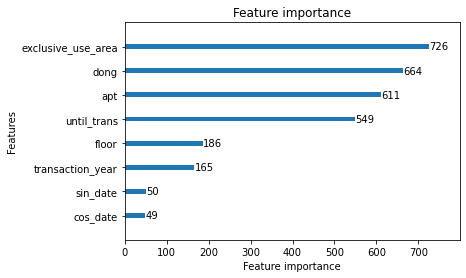

```python
lgb.plot_importance(lgbm_model, grid = False)
```

### 1.3 Randomness Control

```python
import random
import os
```

```python
random.seed(42)
np.random.seed(42)
os.environ["PYTHONHASHSEED"] = str(42)
```

### 1.4 Permutation Feature Importance

```python
from sklearn.inspection import permutation_importance
```

```python
permut_result = permutation_importance(best_lgbm_reg, test_cbe, test_y, random_state = 42)
```

```python
# 배열 형태
pm_importance_values = permut_result.importances_mean

# 시각화를 위한 series 형태
pm_series = pd.Series(pm_importance_values, index = test_cbe.columns)
```

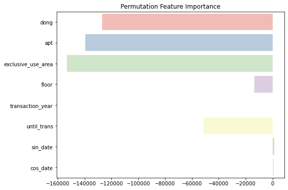

```python
# 시각화
plt.figure(figsize=(8,6))
plt.title('Permutation Feature Importance')
sns.barplot(x = pm_series, y = pm_series.index)
sns.set_palette('Pastel1')
plt.show()
```

### 1.5 SHAP(SHapley Additive exPlanations)의 확인과 해석

```python
import shap
```

```python
# 설명 모델
explainer_model = shap.TreeExplainer(best_lgbm_reg)

# shapely value 계산
shap_values = explainer_model.shap_values(test_cbe)
```

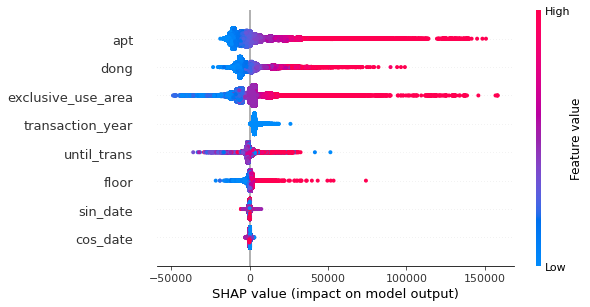

```python
# 시각화
shap.initjs() # 그래프 초기화
shap.summary_plot(shap_values, test_cbe)
```

- apt: 인코딩된 값이 작을수록 예상 가격이 낮고, 클수록 예상 가격이 높은 경향성이 있다.
- dong: 인코딩된 값이 작을수록 예상 가격이 낮고, 클수록 예상 가격이 높은 경향성이 있다.
- exclusive_use_area: 전용 면적이 좁을수록 예상 가격이 낮고, 넓을수록 예상 가격이 높은 경향성이 있다. (전체적으로 가장 중요한 변수는 아니지만, 일부 건물에 있어서 큰 영향력을 미침)
- transaction_year: 값이 작을수록, 즉 과거에 거래된 경우일수록 예상 가격이 높은 경향성이 있다.
- until_trans: 해석이 모호하다.
- floor: 층 수가 낮을수록 예상 가격이 낮고, 층 수가 높을수록 예상 가격이 높은 경향성이 있다.
- sin_date: 해석이 모호하다.
- cos_date: 해석이 모호하다.

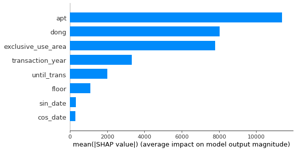

```python
shap.summary_plot(shap_values, test_cbe, plot_type = "bar")
```

변수별 영향력을 나타내는 플랏이다. 위에서부터 순서대로 target인 price와의 관계성이 큰 것으로 예측된다. apt, dong, exclusive_use_area와 같은 변수들이 상위를, sin_date, cos_date가 하위를 차지해 앞서 살펴본 feature importance와 맥락을 같이 하는 것으로 볼 수도 있겠다.

## Chapter 2. 딥러닝 기본

### 2.1 주어진 코드를 실행하고, 현재 신경망의 구조에 대해 간단히 설명해주세요.

```python
train = pd.read_csv('train.csv')
train_x = train.drop(['price'], axis = 1)
train_y = train.loc[:, ['price']]

val_x = train_x[train['transaction_year'] == 4]
val_y = train_y[train['transaction_year'] == 4]
train_tune_x = train_x[train['transaction_year'] < 4]
train_tune_y = train_y[train['transaction_year'] < 4]

CBE_encoder = CatBoostEncoder()
train_tune_cbe = CBE_encoder.fit_transform(train_tune_x[feature_list], train_tune_y)
val_cbe = CBE_encoder.transform(val_x[feature_list])
```

```python
import tensorflow as tf
import keras

from keras import models
from keras import layers
from keras.layers import Dense
from keras.optimizers import Adam
```

```python
def build_model():
    # 레이어 목록을 Sequential 생성자에 전달하여 Sequential 모델 생성
  model = keras.Sequential([
    layers.Dense(256, activation='relu', input_shape=[len(train_tune_cbe.keys())]),
    layers.Dense(64, activation='relu'),
    layers.Dense(32, activation='relu'),
    layers.Dense(1)
  ])

  optimizer = tf.keras.optimizers.RMSprop(0.0001) # RMSprop 알고리즘, Adagrad에서 학습률이 급격하게 감소하는 문제를 해결

  model.compile(loss='mse',
                optimizer=optimizer,
                metrics=['mse'])
  return model
```

```python
model = build_model()
model.summary()
```

```
Model: "sequential"
_________________________________________________________________
Layer (type)                 Output Shape              Param #
=================================================================
dense (Dense)                (None, 256)               2304
_________________________________________________________________
dense_1 (Dense)              (None, 64)                16448
_________________________________________________________________
dense_2 (Dense)              (None, 32)                2080
_________________________________________________________________
dense_3 (Dense)              (None, 1)                 33
=================================================================
Total params: 20,865
Trainable params: 20,865
Non-trainable params: 0
_________________________________________________________________
```

- dense, dense_1, dense_2, dense_3이라는 이름의 Dense 레이어가 생성되었다.
- Output shape의 (None, n)에서 None은 행 개수, n은 output 값 개수를 뜻한다. 모든 레이어의 행 개수는 None이며 첫번째 레이어의 output 개수는 256개, 두번째는 64개, 세번째는 32개, 네번째는 1개이다. 딥러닝 모델은 데이터가 계속해서 추가될 수 있음을 고려해 행을 무시하고 열의 shape을 맞추어주고자 한다.
- 세번째 열에 나타난 Param #은 파라미터의 수, 즉 각 입력노드와 출력노드에 대해 연결된 간선의 수를 뜻한다. 인풋 노드 개수에 아웃풋 개수를 곱해 계산되며, 이때 인풋 노드 개수는 입력값의 개수에 Bias 노드의 개수를 합한 값이다. 따라서 첫번째 레이어에는 2304개, 두번째에는 16448개, 세번째에는 2080개, 네번째에는 33개의 파라미터가 존재하게 된다.

### 2.2 training loss와 validation loss를 시각화하세요.

```python
# epochs: 학습 반복 횟수
# batch_size: 가중치 갱신에 사용할 샘플 개수
history = model.fit(train_tune_cbe, train_tune_y, epochs=300, validation_data = (val_cbe, val_y), batch_size = 512, verbose = False)
```

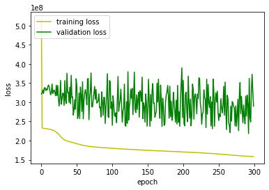

```python
fig, loss_ax = plt.subplots()

loss_ax.plot(history.history['loss'], 'y', label='training loss')
loss_ax.plot(history.history['val_loss'], 'g', label='validation loss')

loss_ax.set_xlabel('epoch')
loss_ax.set_ylabel('loss')

loss_ax.legend(loc='upper left')

plt.show()
```

### 2.4 더 좋은 성능의 딥러닝 모델을 위해

```python
feature_list = list(train_x.columns)

CBE_encoder = CatBoostEncoder()
train_cbe = CBE_encoder.fit_transform(train_x[feature_list], train_y)
test_cbe = CBE_encoder.transform(test_x[feature_list])
```

```python
from keras.layers import BatchNormalization, Activation, Dropout
```

overfitting 완화를 위해,

- weight regularization: 손실 함수에 큰 가중치에 해당하는 비용을 추가해 가중치가 작은 값을 가지도록 함으로써 네트워크의 복잡도에 제약을 가함(가중치의 분포를 좀 더 균일하게)
- batch normalization: gradient vanishing & gradient exploding이 일어나지 않도록 하는 아이디어 중의 하나, 학습 속도 빨라짐
- dropout: 학습 시킬 때 뉴런을 무작위로 제외 (비율은 일반적으로 0.5 ~ 0.8)
- epoch: 너무 큰 값은 overfitting, 너무 작은 값은 underfitting

(+) batch normalization 논문의 저자는 이것이 dropout을 대체할 수 있다고 하였으나, 실제로는 같이 사용했을 때 학습 결과가 더 좋기도 함.

```python
# 평가 결과 그래프 그리기
def plot_history(histories, key='mse'):
  plt.figure(figsize=(16,10))

  for name, history in histories:
    val = plt.plot(history.epoch, history.history['val_'+key],
                   '--', label=name.title()+' Val')
    plt.plot(history.epoch, history.history[key], color=val[0].get_color(),
             label=name.title()+' Train')

  plt.xlabel('Epochs')
  plt.ylabel(key.replace('_',' ').title())
  plt.legend()

  plt.xlim([0,max(history.epoch)])
```

```python
# 시초 모델
baseline = model.fit(train_cbe, train_y, epochs=300, validation_data = (test_cbe, test_y), batch_size = 512, verbose = False)
```

```python
# (1) 드롭 아웃
def dropout_model():
  model = keras.Sequential([
    layers.Dense(256, activation='relu', input_shape=[len(train_tune_cbe.keys())]),
    layers.Dropout(0.5),
    layers.Dense(64, activation='relu'),
    layers.Dropout(0.5),
    layers.Dense(32, activation='relu'),
    layers.Dropout(0.5),
    layers.Dense(1)
  ])

  optimizer = tf.keras.optimizers.RMSprop(0.0001)

  model.compile(loss='mse',
                optimizer=optimizer,
                metrics=['mse'])
  return model
```

```python
drpt = dropout_model()
dropout = drpt.fit(train_cbe, train_y, epochs=300, validation_data = (test_cbe, test_y), batch_size = 512, verbose = False)
```

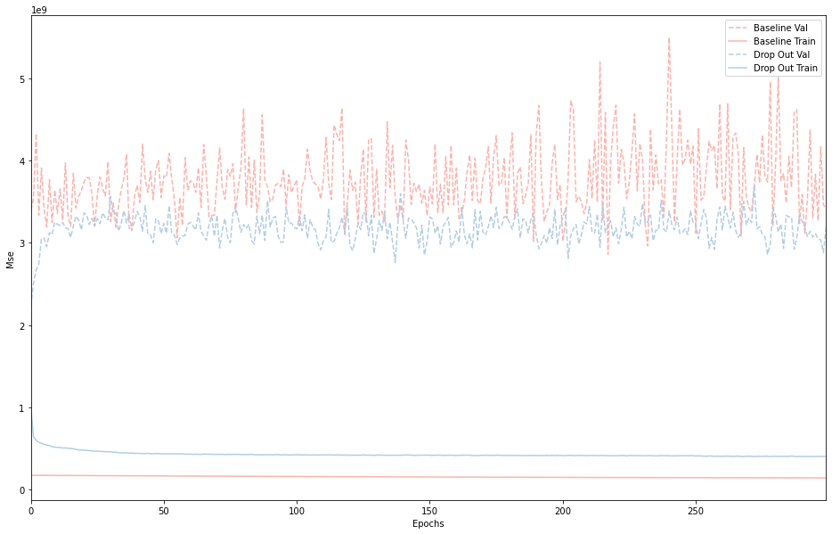

```python
plot_history([('baseline', baseline),
              ('drop out', dropout)])
```

```python
# (2) 정규화 & 드롭 아웃
def normndrop_model():
  model = keras.Sequential([
    layers.Dense(256, input_shape=[len(train_tune_cbe.keys())]),
    layers.BatchNormalization(),
    layers.Activation('relu'),
    layers.Dropout(0.5),
    layers.Dense(64),
    layers.BatchNormalization(),
    layers.Activation('relu'),
    layers.Dropout(0.5),
    layers.Dense(32),
    layers.BatchNormalization(),
    layers.Activation('relu'),
    layers.Dropout(0.5),
    layers.Dense(1)
  ])

  optimizer = tf.keras.optimizers.RMSprop(0.0001)

  model.compile(loss='mse',
                optimizer=optimizer,
                metrics=['mse'])
  return model
```

```python
normndrop = normndrop_model()
normaldrop = normndrop.fit(train_cbe, train_y, epochs=300, validation_data = (test_cbe, test_y), batch_size = 512, verbose = False)
```

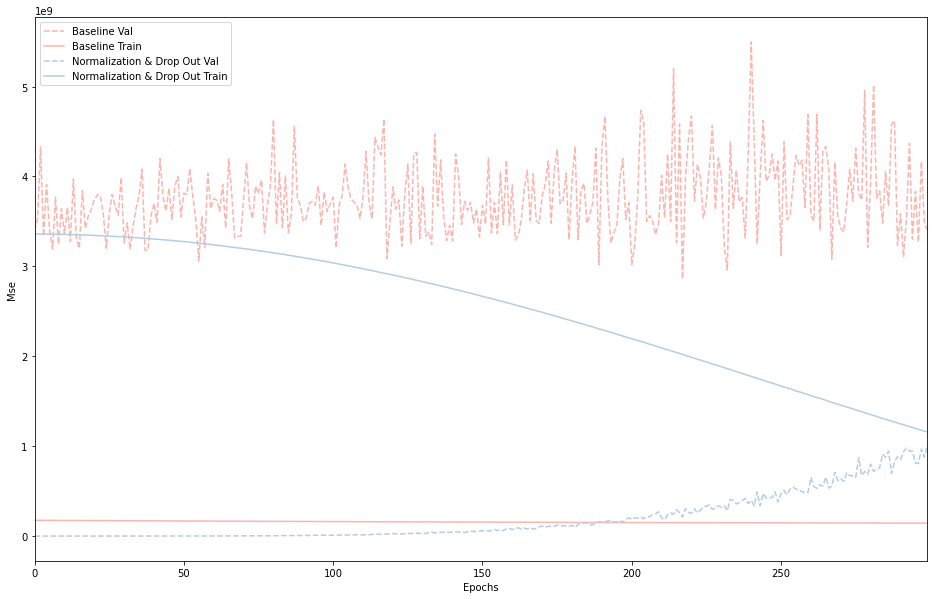

```python
plot_history([('baseline', baseline),
              ('normalization & drop out', normaldrop)])
```

```python
# (3) weight regularization
def reg_model():
  model = keras.Sequential([
    layers.Dense(256, kernel_regularizer=keras.regularizers.l2(0.001), activation='relu',input_shape=[len(train_tune_cbe.keys())]),
    layers.Dense(64, kernel_regularizer=keras.regularizers.l2(0.001), activation='relu'),
    layers.Dense(32, kernel_regularizer=keras.regularizers.l2(0.001), activation='relu'),
    layers.Dense(1, kernel_regularizer=keras.regularizers.l2(0.001), activation='relu')
  ])

  optimizer = tf.keras.optimizers.RMSprop(0.0001)
  model.compile(loss='mse',
                optimizer=optimizer,
                metrics=['mse'])
  return model
```

```python
regul = reg_model()
regular = regul.fit(train_cbe, train_y, epochs=300, validation_data = (test_cbe, test_y), batch_size = 512, verbose = False)
```

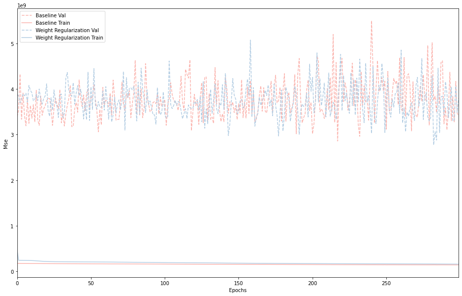

```python
plot_history([('baseline', baseline),
              ('weight regularization', regular)])
```

```python
## (4) 정규화 & 드롭 아웃 + 레이어 output 개수 조정
def normndropnoutput_model():
  model = keras.Sequential([
    layers.Dense(128, input_shape=[len(train_tune_cbe.keys())]),
    layers.BatchNormalization(),
    layers.Activation('relu'),
    layers.Dropout(0.5),
    layers.Dense(32),
    layers.BatchNormalization(),
    layers.Activation('relu'),
    layers.Dropout(0.5),
    layers.Dense(16),
    layers.BatchNormalization(),
    layers.Activation('relu'),
    layers.Dropout(0.5),
    layers.Dense(1)
  ])

  optimizer = tf.keras.optimizers.RMSprop(0.0001)

  model.compile(loss='mse',
                optimizer=optimizer,
                metrics=['mse'])
  return model
```

```python
normndropnoutput = normndropnoutput_model()
normaldropoutput = normndropnoutput.fit(train_cbe, train_y, epochs=300, validation_data = (test_cbe, test_y), batch_size = 512, verbose = False)
```

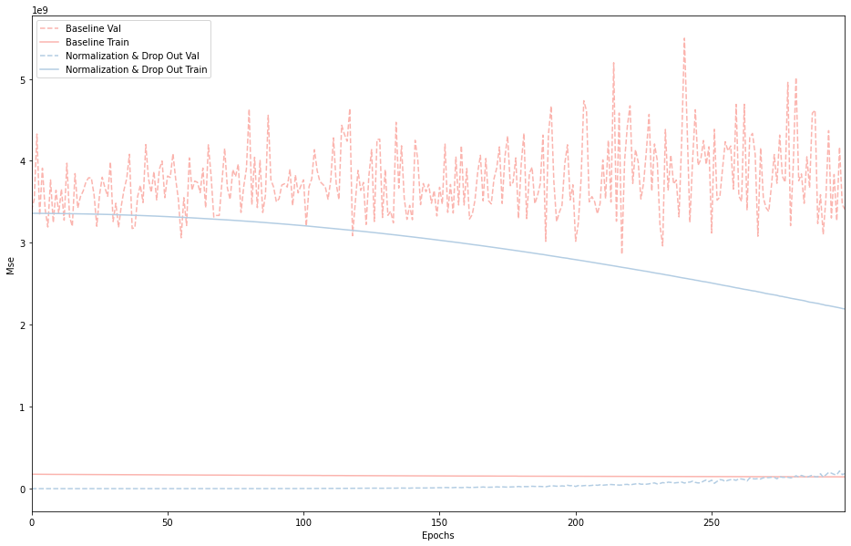

```python
plot_history([('baseline', baseline),
              ('normalization & drop out', normaldropoutput)])
```